# Research Computing Bootcamp

Boston University

## R Track: Part 4 - Using Statistical Tools for Data Analysis

Discovering and verifying meaningful patterns and correlations in data requires quantitative techniques that can analyze the data in a rigorous mathematical or algorithmic way. Part Four presents how to use various basic statistical tools to analyze the example dataset. The use of these tools is demonstrated and various example diagnostics, patterns, and correlations are examined in the example dataset.

```r
library(readr)
library(ggplot2)
library(dplyr)
```

Let’s read the two dataset we explored in the previous workshops:

```r
USA.health <- read_csv("https://github.com/bu-rcs/bu-rcs.github.io/raw/main/Bootcamp/Data/USA_HealthData.csv") %>%
  rename(poor_health = "% Fair or Poor Health",
         p_smokers = "% Smokers",
         p_obese = "% Adults with Obesity",
         p_inactive = "% Physically Inactive",
         p_college="% Some College",
         p_housing_problems = "% Severe Housing Problems") %>%
  select(State, County, poor_health : p_inactive, p_college, p_housing_problems) %>%
  filter( !is.na(County) )



USA.demogr <- read_csv("https://github.com/bu-rcs/bu-rcs.github.io/raw/main/Bootcamp/Data/USA_DemographicsData.csv") %>%
  rename( life_exp = "Life Expectancy",
          ph_distress = "% Frequent Physical Distress",
          limit_healthy_food = "% Limited Access to Healthy Foods",
          house_income = "Median Household Income",
          N_black = "# Black",
          N_rural = "# Rural") %>%
  select(State : house_income, Population, N_black, N_rural) %>%
  filter( !is.na(County) )


USA.data <- inner_join( USA.health, USA.demogr, by = c("State", "County"))


USA.regions <- read_csv("https://github.com/bu-rcs/bu-rcs.github.io/raw/main/Bootcamp/Data/us_states_census_regions.csv")

# Add the names of Regions
USA.data <- merge(USA.data, USA.regions, by = "State")

glimpse (USA.data)
```

```
## Rows: 3,142
## Columns: 16
## $ State              <chr> "Alabama", "Alabama", "Alabama", "Alabama", "Ala...
## $ County             <chr> "Autauga", "Baldwin", "Barbour", "Bibb", "Blount...
## $ poor_health        <dbl> 20.88299, 17.50913, 29.59180, 19.43972, 21.74529...
## $ p_smokers          <dbl> 18.08156, 17.48903, 21.99998, 19.11420, 19.20867...
## $ p_obese            <dbl> 33.3, 31.0, 41.7, 37.6, 33.8, 37.2, 43.3, 38.5, ...
## $ p_inactive         <dbl> 34.7, 26.5, 23.5, 33.5, 30.3, 24.6, 39.5, 31.7, ...
## $ p_college          <dbl> 62.00997, 67.37162, 34.85765, 44.13735, 53.36107...
## $ p_housing_problems <dbl> 14.663462, 13.566201, 14.583333, 10.496454, 10.5...
## $ life_exp           <dbl> 76.87948, 78.45026, 75.34193, 73.57182, 74.14583...
## $ ph_distress        <dbl> 13.68523, 12.48011, 17.18490, 13.62658, 14.52316...
## $ limit_healthy_food <dbl> 11.9911250, 5.4244266, 10.7396666, 2.6016270, 2....
## $ house_income       <dbl> 59338, 57588, 34382, 46064, 50412, 29267, 37365,...
## $ Population         <dbl> 55601, 218022, 24881, 22400, 57840, 10138, 19680...
## $ N_black            <dbl> 10755, 19151, 11951, 4731, 846, 7050, 8769, 2382...
## $ N_rural            <dbl> 22921, 77060, 18613, 15663, 51562, 5607, 14921, ...
## $ Region             <chr> "East South Ctr", "East South Ctr", "East South ...
```

### Hypothesis Testing in R

1. State Hypothesis
2. Formulate an analysis plan
3. Perform analysis
4. Interpret results

**Type I Error** - null hypothesis is rejected when it is true. *significance level* - probability of Type I error (represented by $\alpha$ symbol)

**Type II Error** - accepting a false null hypothesis. *power* of the test - probability of Type II error (represented by $\beta$ symbol)

### Checking if a variable normally distributed

Let’s take a look at the *life expectancy* variable.

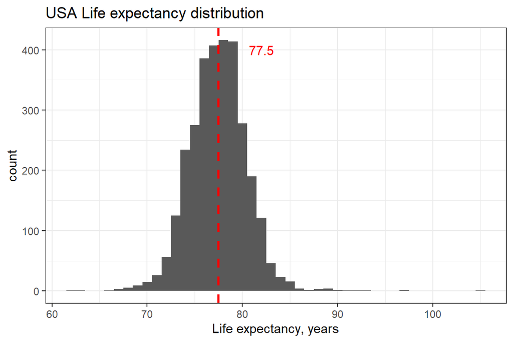

```r
ggplot( USA.data, aes (life_exp) ) +
  geom_histogram(binwidth=1) +
  geom_vline(xintercept=median(USA.data$life_exp, na.rm=T),
             linetype="dashed", color = "red", size=1.) +
  ggtitle ("USA Life expectancy distribution") +
  xlab( "Life expectancy, years") +
  annotate(geom="text",
           x=82, y=400,
           label=round(median(USA.data$life_exp, na.rm=T),1),
           color="red") +
  theme_bw()
```

Is this variable normally distributed?

Let’s first perform some *visual* analysis

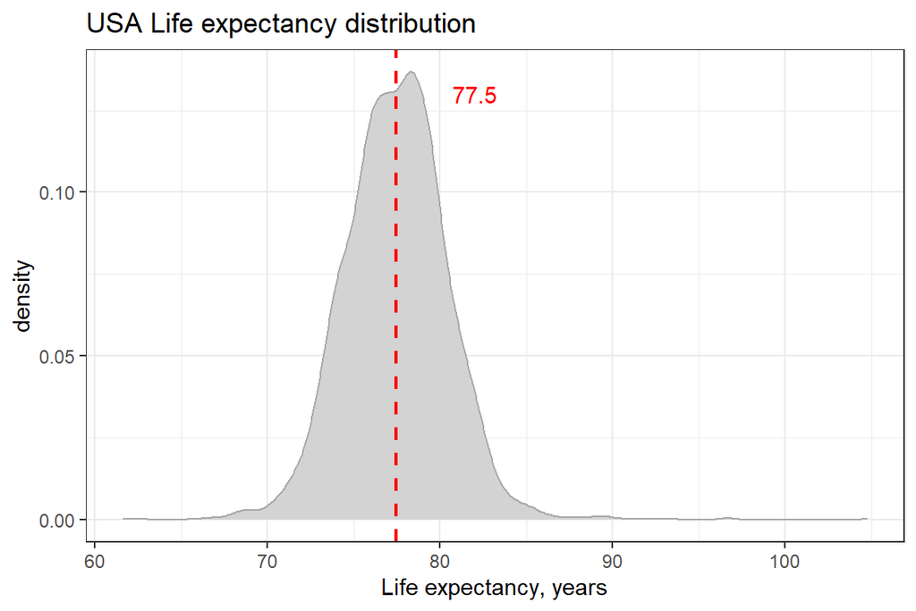

```r
ggplot( USA.data, aes (life_exp) ) +
  geom_density(color="darkgray", fill="lightgrey") +
  geom_vline(xintercept=median(USA.data$life_exp, na.rm=T),
             linetype="dashed", color = "red", size=.8) +
  ggtitle ("USA Life expectancy distribution") +
  xlab( "Life expectancy, years") +
  annotate(geom="text",
           x=82, y=0.13,
           label=round(median(USA.data$life_exp, na.rm=T),1),
           color="red") +
  theme_bw()
```

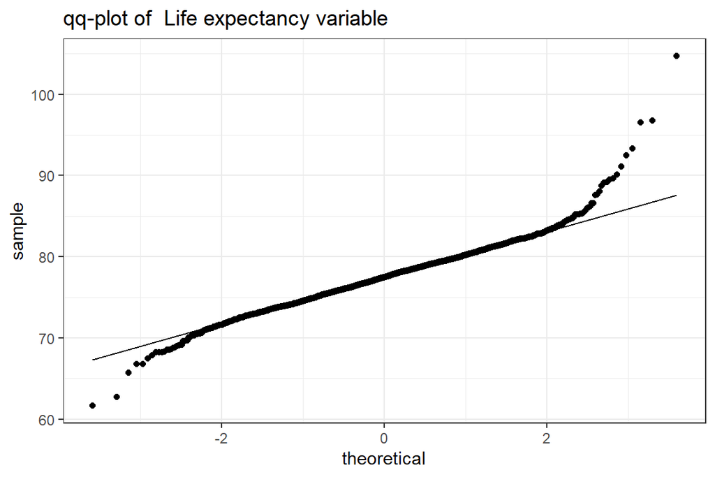

```r
ggplot( USA.data, aes (sample = life_exp) ) +
  stat_qq() + stat_qq_line() +
  ggtitle ("qq-plot of  Life expectancy variable") +
  theme_bw()
```

1. **State Hypothesis**:

*Null-hypothesis* - the sample comes from a normal distribution. *Alternative hypothesis* - the sample does not come from a normal distribution

2. **Formulate an analysis plan**

We will run [*Shapiro-Wilks*](http://www.sthda.com/english/wiki/normality-test-in-r) test of normality.

3. **Perform analysis**

```r
shapiro.test(USA.data$life_exp)
```

```
##
##  Shapiro-Wilk normality test
##
## data:  USA.data$life_exp
## W = 0.97168, p-value < 2.2e-16
```

4. **Interpret results**

From the output, the p-value < 0.05 implying that the distribution of the data is significantly different from normal distribution. So we reject the *Null Hypothesis* - data are not normally distributed

### Comparing two samples

Let’s compare Life expectancy in New England and East South Ctr Region. Let’s first summarize our data and find median and mean values

```r
USA.data %>%
  group_by(Region) %>%
  summarise ( mean = mean(life_exp, na.rm=T), median = median(life_exp, na.rm=T))
```

| Region | mean | median |
| --- | --- | --- |
| East North Ctr | 77.74159 | 77.76533 |
| East South Ctr | 74.52239 | 74.45971 |
| Mid. Atl. | 78.97253 | 78.67613 |
| New. Eng | 79.50014 | 79.47139 |
| South Atl. | 76.83191 | 76.64232 |
| West North Ctr | 78.52423 | 78.78636 |
| West South Ctr | 77.83718 | 77.64329 |

Let’s visually compare two distributions of this variable for both regions

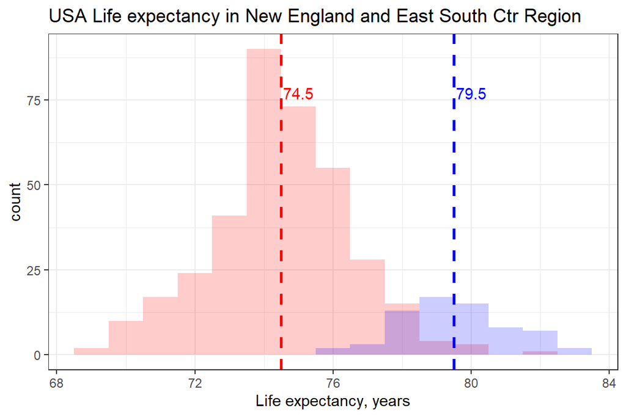

```r
ggplot( USA.data, aes (x=life_exp) ) +
  geom_histogram(data = subset(USA.data, Region == "East South Ctr"),
                 binwidth=1, fill = "red", alpha = 0.2) +
  geom_histogram(data = subset(USA.data, Region == "New. Eng"),
                 binwidth=1, fill = "blue", alpha = 0.2) +
  geom_vline(xintercept=74.5,
             linetype="dashed", color = "red", size=1.) +
  geom_vline(xintercept=79.5,
             linetype="dashed", color = "blue", size=1.) +
  ggtitle ("USA Life expectancy in New England and East South Ctr Region") +
  xlab( "Life expectancy, years") +
  annotate(geom="text",
           x=75, y=77,
           label=74.5,
           color="red") +
    annotate(geom="text",
           x=80, y=77,
           label=79.5,
           color="blue") +
  theme_bw()
```

1. **State Hypothesis**:

*Null-hypothesis* - difference in means is equal to 0. *Alternative hypothesis* - true difference in means is not equal to 0.

2. **Formulate an analysis plan**

We will run [*Welch Two Sample t-test*](https://www.datanovia.com/en/lessons/types-of-t-test/unpaired-t-test/welch-t-test/).

3. **Perform analysis**

```r
x <- USA.data$life_exp[USA.data$Region == "New. Eng"]
y <- USA.data$life_exp[USA.data$Region == "East South Ctr"]
t.test(x,y)
```

```
##
##  Welch Two Sample t-test
##
## data:  x and y
## t = 22.997, df = 109.79, p-value < 2.2e-16
## alternative hypothesis: true difference in means is not equal to 0
## 95 percent confidence interval:
##  4.548782 5.406709
## sample estimates:
## mean of x mean of y
##  79.50014  74.52239
```

4. **Interpret results**

From the output, the p-value < 0.05 implying that the true difference in means is not equal to zero and we can reject *Null Hypothesis*. It’s always a good idea to include in your report the 95% percent confidence interval and other statistics along with the p-value.

#### **Exercise**

1. Check if the variable *house_income* normally distributed
2. Perform Welch t.test to compare *house_income* between New England Region and East South Ctr

### Correlation and Covariance

From our previous sessions we saw that there is correlation between percent of smokers in a County and *poor health* variable:

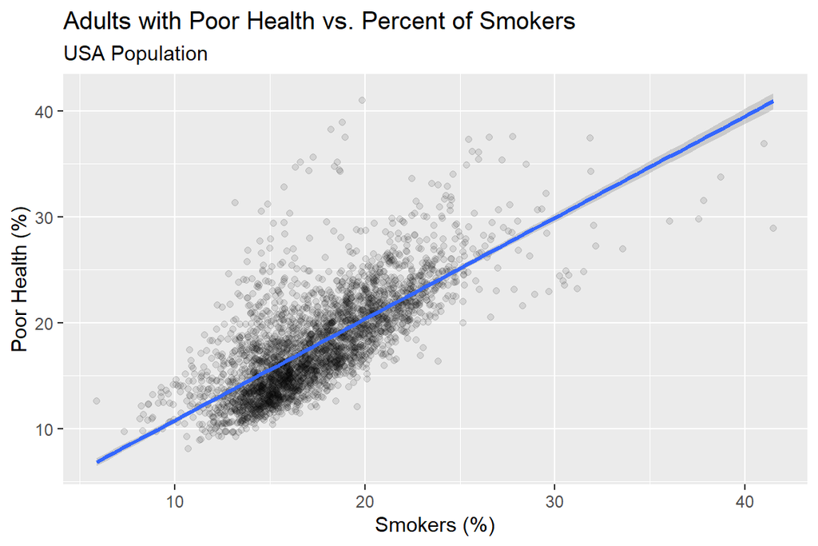

```r
ggplot( USA.data, aes(x = p_smokers, y = poor_health)) +
  geom_point(alpha=0.1) +
  geom_smooth(method = "lm") +
    labs( title = "Adults with Poor Health vs. Percent of Smokers",
        subtitle="USA Population",
        x =  "Smokers (%)",
        y = "Poor Health (%)")
```

The `cor()` function calculates correlations between two vectors.

The `cov()` functions computes covariance.

The `cor.test()` function performs test of significance of the correlation.

```r
cor( USA.data$p_smokers, USA.data$poor_health)
```

```
## [1] 0.7288778
```

```r
cov( USA.data$p_smokers, USA.data$poor_health)
```

```
## [1] 12.47293
```

```r
cor.test( USA.data$p_smokers, USA.data$poor_health)
```

```
##
##  Pearson's product-moment correlation
##
## data:  USA.data$p_smokers and USA.data$poor_health
## t = 59.656, df = 3140, p-value < 2.2e-16
## alternative hypothesis: true correlation is not equal to 0
## 95 percent confidence interval:
##  0.7120582 0.7448614
## sample estimates:
##       cor
## 0.7288778
```

#### **Exercise**

Find correlation, covariance and perform test for correlation between *p_college* and *p_smokers* variables.

### Chi-square test of independence

Let’s assign a label to each County based on the median household income:

```r
USA.data_extra <- USA.data %>%
  mutate( wealth = case_when(house_income < 50000 ~ "low",
                             house_income > 80000 ~ "high",
                             TRUE ~ "middle"))

table(USA.data_extra$wealth)
```

```
##
##   high    low middle
##    155   1497   1490
```

We would like to test if there is a relationship between two categorical variables: *wealth* and *Region*.

Let’s first create a contingency table of these two variables:

```r
table(USA.data_extra$Region, USA.data_extra$wealth)
```

```
##
##                  high low middle
##   East North Ctr   18 137    282
##   East South Ctr    3 284     77
##   Mid. Atl.        20  30    100
##   New. Eng         10  12     45
##   South Atl.       41 346    201
##   West North Ctr   15 227    376
##   West South Ctr   48 461    409
```

Let’s also draw a barplot to visually represent the data:

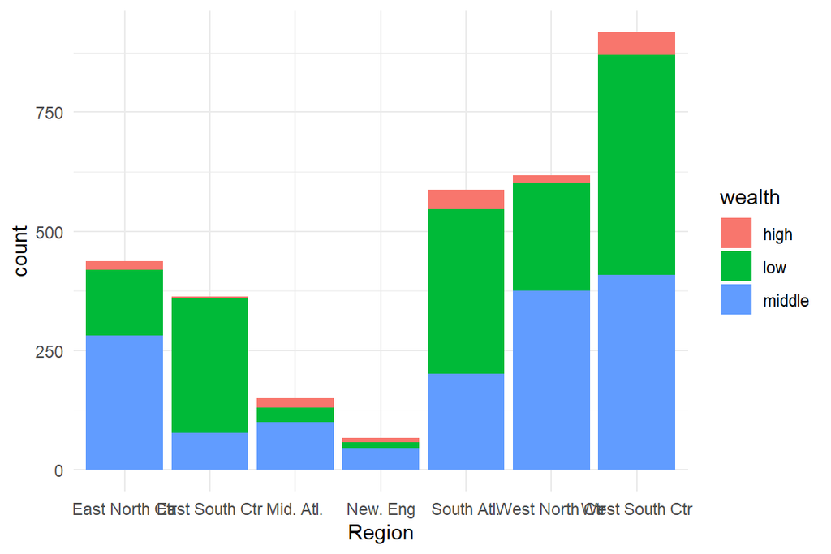

```r
ggplot(USA.data_extra) +
  aes(x = Region, fill = wealth) +
  geom_bar() +
  scale_fill_hue() +
  theme_minimal()
```

1. **State Hypothesis**:

*Null-hypothesis* - The variables *Region* and *wealth* are independent, there is no relationship between these two categorical variables. *Alternative hypothesis* - the variables are dependent. Knowing the value of one variable helps to predict the value of the other variable.

2. **Formulate an analysis plan**

We will run [*Chi-square test of independence*](http://www.sthda.com/english/wiki/chi-square-test-of-independence-in-r).

3. **Perform analysis**

```r
res <- chisq.test( table(USA.data_extra$Region, USA.data_extra$wealth) )
```

```
## Warning in chisq.test(table(USA.data_extra$Region, USA.data_extra$wealth)): Chi-
## squared approximation may be incorrect
```

```r
res
```

```
##
##  Pearson's Chi-squared test
##
## data:  table(USA.data_extra$Region, USA.data_extra$wealth)
## X-squared = 368.55, df = 12, p-value < 2.2e-16
```

When a warning such as *Chi-squared approximation may be incorrect* appears, it means that the smallest expected frequencies is lower than 5. To avoid this issue, we can either gather some levels or use the *Fisher’s exact test*.

4. **Interpret results**

From the output, the p-value < 0.05 implying that we can reject the Null hypothesis and state that there is a significant relationship between the *Region* and *wealth* variables.

### Linear Regression

**Regression analysis** is a statistical technique for determining the relationship between two or more than two variables.

*Simple Linear Regression* - single explanatory variable

*Multiple Linear Regression* - the value of the dependent variable depends on more than one explanatory variable.

In order to visualise the linear relationship between independent and dependent variables we use a scatterplot:

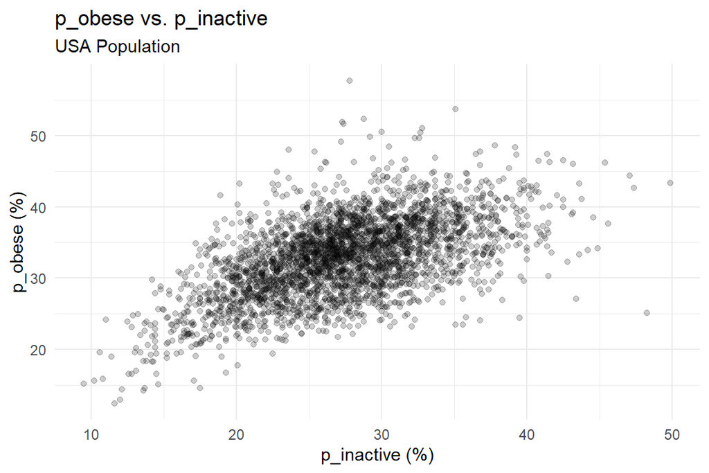

```r
ggplot(USA.data) +
  aes(x = p_inactive, y = p_obese) +
  geom_point( alpha = .2) +
  labs( title = "p_obese vs. p_inactive",
        subtitle="USA Population",
        x =  "p_inactive (%)",
        y = "p_obese (%)")+
  theme_minimal()
```

We can compute compute correlation between these two variables:

```r
cor( USA.data$p_obese,  USA.data$p_inactive)
```

```
## [1] 0.5599775
```

Now we can run linear regression:

```r
lm.fit <- lm( p_obese ~ p_inactive, data = USA.data)
summary(lm.fit)
```

```
##
## Call:
## lm(formula = p_obese ~ p_inactive, data = USA.data)
##
## Residuals:
##      Min       1Q   Median       3Q      Max
## -18.9746  -3.0510   0.1491   2.8890  24.6111
##
## Coefficients:
##             Estimate Std. Error t value Pr(>|t|)
## (Intercept) 18.19122    0.39554   45.99   <2e-16 ***
## p_inactive   0.53589    0.01415   37.87   <2e-16 ***
## ---
## Signif. codes:  0 '***' 0.001 '**' 0.01 '*' 0.05 '.' 0.1 ' ' 1
##
## Residual standard error: 4.518 on 3140 degrees of freedom
## Multiple R-squared:  0.3136, Adjusted R-squared:  0.3134
## F-statistic:  1434 on 1 and 3140 DF,  p-value: < 2.2e-16
```

R^2 allows us to measure how good this model is. In our case *R-squared* is about 0.3. So our model explains only 30% of the data variability.

We also should look at the residuals. Their plot should look random - we should see no patterns:

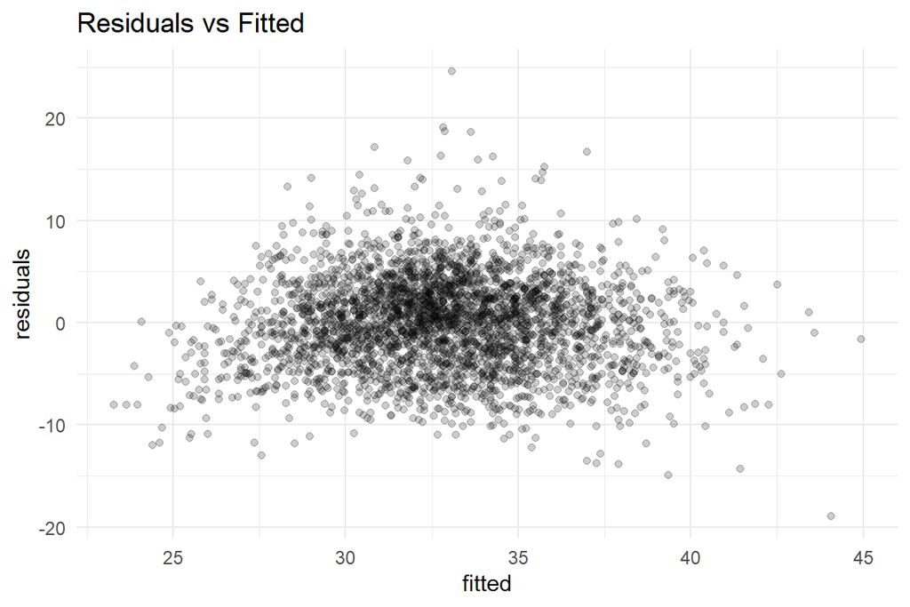

```r
residuals <- lm.fit$residuals
fitted <- lm.fit$fitted.values

res <- data.frame(residuals,fitted )
ggplot(res, aes(x = fitted, y = residuals)) +
  geom_point(alpha = 0.2) +
  labs(title = "Residuals vs Fitted") +
  theme_minimal()
```

#### **Exercise**

Perform linear regression for variables *poor_health* and *p_smokers*.

#### Read more:

- [T.test](http://www.sthda.com/english/wiki/t-test-analysis-is-it-always-correct-to-compare-means#t-test)
- [Correlation analysis](http://www.sthda.com/english/wiki/correlation-test-between-two-variables-in-r#correlation-formula)
- [Chi-square test of independence](http://www.sthda.com/english/wiki/chi-square-test-of-independence-in-r)
- [Linear Regression](https://www.datacamp.com/community/tutorials/linear-regression-R)